# ETSP Microbiome and *Plasmodium*

## Import 16S Data

Start by importing Mothur-generated dataset and metadata from 2020 using the package phyloseq. Combine the files into a single phyloseq object.

```r
library(tidyverse)
library(ggplot2)
library(phyloseq)
library(readxl)

##Import data from 2020 and make into phyloseq object
mothur_20 <- import_mothur(mothur_shared_file = "~/Research/Plas_microbiome_submission/R_files/ETSP_batch1_2020.shared",
                           mothur_constaxonomy_file = "~/Research/Plas_microbiome_submission/R_files/ETSP_batch1_2020.taxonomy")
metadata_20 <- read_excel(path="~/Research/Plas_microbiome_submission/R_files/metadata_2020.xlsx")
map_20 <- sample_data(metadata_20) # convert metadata into phyloseq sample_data
rownames(map_20) <-map_20$id  #fix problem recognizing sample names
etsp_20 <- merge_phyloseq(map_20, mothur_20)
sample_names(etsp_20)
```

Now import the 16S dataset from 2021 using the same steps.

```r
##Import data from 2021 and make into phyloseq object
mothur_21 <- import_mothur(mothur_shared_file = "~/Research/Plas_microbiome_submission/R_files/ETSP_batch2_2021.shared", mothur_constaxonomy_file = "~/Research/Plas_microbiome_submission/R_files/ETSP_batch2_2021.taxonomy")
metadata_21 <- read_excel(path="~/Research/Plas_microbiome_submission/R_files/metadata_2021.xlsx")
map_21 <- sample_data(metadata_21) # convert metadata into phyloseq sample_data
rownames(map_21) <-map_21$id  #fix problem recognizing sample names
etsp_21 <- merge_phyloseq(map_21, mothur_21)
sample_names(etsp_21)
```

Merge both datasets from 2020 and 2021 into a single phyloseq object. Label rank names.

```r
all_data <- merge_phyloseq(etsp_20, etsp_21)

rank_names(all_data)
colnames(tax_table(all_data)) <- c("Kingdom", "Phylum", "Class", "Order", "Family", "Genus" )
rank_names(all_data)

sample_names(all_data)
```

Use the package decontam to detect potential contaminants from the negative controls and to remove them from the dataset. Then remove all non-sparrow samples (e.g. controls) from the dataset.

```r
library(decontam)

dec <- subset_samples(all_data, decontam!="NA")

#Prevalence method - decontam
sample_data(dec)$is.neg <- sample_data(dec)$decontam == "negative"
contamdf.prev <- isContaminant(dec, method="prevalence", neg="is.neg")
table(contamdf.prev$contaminant)
##FALSE   TRUE
##11334     2
head(which(contamdf.prev$contaminant))
##[1]   59 7350

# Make phyloseq object of presence-absence in negative controls and samples
ps.pa <- transform_sample_counts(dec, function(abund) 1*(abund>0))
ps.pa.neg <- prune_samples(sample_data(ps.pa)$decontam == "negative", ps.pa)
ps.pa.pos <- prune_samples(sample_data(ps.pa)$decontam == "sample", ps.pa)
# Make data.frame of prevalence in positive and negative samples
df.pa <- data.frame(pa.pos=taxa_sums(ps.pa.pos), pa.neg=taxa_sums(ps.pa.neg),
                    contaminant=contamdf.prev$contaminant)
ggplot(data=df.pa, aes(x=pa.neg, y=pa.pos, color=contaminant)) + geom_point() +
  xlab("Prevalence (Negative Controls)") + ylab("Prevalence (Samples)")

##Remove contaminants from samples
dec
clean_ps <- prune_taxa(!contamdf.prev$contaminant, dec)
clean_ps

#Remove negative controls, leaving cleaned sparrow samples from Columbia Bottom CA and Webster Groves.
clean_ps <- subset_samples(clean_ps, decontam=="sample")
clean_ps
```

Remove unclassified bacteria, check sample read depth, and subsample to 4422 reads. This excludes 6 samples.

```r
clean_ps <- subset_taxa(clean_ps, Phylum != "Bacteria_unclassified")
sort(phyloseq::sample_sums(clean_ps))
twosites <- rarefy_even_depth(clean_ps, sample.size = 4422,
                         rngseed = TRUE, replace = TRUE, trimOTUs = TRUE, verbose = TRUE)
sample_names(twosites)
sample_sums(twosites)
sample_data(twosites)$id

#Fix name issue in one sample (aesthetic change for graph)
sample_data(twosites)$id <- c("BLU001", "BLU005", "BLU009", "BLU010",  "BLU012",  "BLU013", "BLU015",  "BLU017",  "BLU019",  "BLU020",  "BLU022",  "BLU023", "BLU024",  "BLU025",  "BLU026",  "BLU027",  "BLU029",  "BLU033",  "BLU038",  "BLU039",  "BLU040",  "BLU041",  "BLU042",  "BLU043", "BLU045",  "ORA001",  "ORA002",  "ORA008",  "ORA010",  "ORA014",  "ORA028",  "ORA031",  "ORA038",  "ORA039",  "ORA040", "ORA041",  "ORA042",  "ORA044",  "ORA047",  "ORA055",  "BLA029",  "BLA039",  "BLA041",  "BLU44R", "BLU048",  "BLU050",  "BLU051", "BLU052",  "BLU056",  "BLU060",  "BLU064",  "BLU066",  "BLU067",  "BLU068",  "BLU070",  "BLU071",  "BLU072",  "BLU073",  "BLU074", "BLU075",  "NAV025",  "NAV037",  "ORA059",  "ORA060",  "ORA063",  "ORA065",  "ORA066",  "ORA069",  "ORA071",  "ORA073",  "ORA076", "ORA077",  "ORA079",  "ORA082",  "ORA084",  "ORA085",  "ORA087",  "ORA090",  "ORA096",  "WHI027",  "WHI028",  "WHI029")

sample_data(twosites)$id
```

##Visualizing Diversity Plot Phyla and Families between disease states. First convert phyloseq object into a data frame, add a column for relative abundance, and sort by relative abundance.

```r
wc_df <- psmelt(twosites)

wc_df <- mutate(wc_df, rel_abund=Abundance/4422)
wc_agg_phylum_data <- group_by(wc_df, Sample, Phylum) %>%
  summarize(agg_rel_abund=sum(rel_abund)) %>%
  ungroup()
wc_agg_phylum_data %>%
  group_by(Phylum) %>%
  summarize(mean=mean(agg_rel_abund)) %>%
  arrange((desc(mean)))

##Phylum
##Firmicutes    4.730891e-01
##Proteobacteria    2.569818e-01
##Actinobacteria    1.851640e-01
##Planctomycetes    2.574477e-02
##Cyanobacteria 2.453505e-02
##Epsilonbacteraeota    1.114907e-02
##Verrucomicrobia   8.040302e-03
##Chloroflexi   6.953186e-03
##Acidobacteria 2.166059e-03
##Bacteroidetes 1.874527e-03
```

Plot the ten top phyla.

```r
library(tidyverse)

wc_top_phyla <- wc_agg_phylum_data %>%
  group_by(Phylum) %>%
  summarize(mean=mean(agg_rel_abund)) %>%
  arrange((desc(mean))) %>%
  top_n(10, mean) %>%
  pull(Phylum)
wc_top_phyla
```

```
## [1] "Firmicutes"         "Proteobacteria"     "Actinobacteria"     "Planctomycetes"     "Cyanobacteria"
## [6] "Epsilonbacteraeota" "Verrucomicrobia"    "Chloroflexi"        "Acidobacteria"      "Bacteroidetes"
```

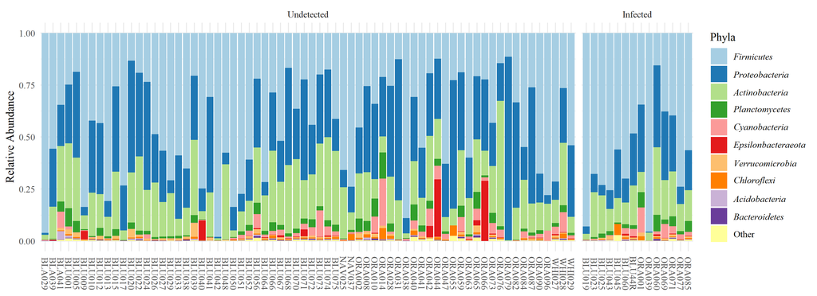

```r
wcphyla <- wc_df %>% mutate(Phylum = fct_other(Phylum, wc_top_phyla))
wcphyla$Phylum <- factor(wcphyla$Phylum, levels = c("Firmicutes", "Proteobacteria", "Actinobacteria",
                                            "Planctomycetes", "Cyanobacteria", "Epsilonbacteraeota", "Verrucomicrobia",
                                            "Chloroflexi", "Acidobacteria", "Bacteroidetes", "Other"))
#df0$id <- factor(df0$id, levels = c("GAPE1808", "GAPE1809", "GAPE1812", "GAPE1832", "GAPE1833",
#                                    "GAPE1834", "GAPE1838", "GAPE1841", "GAPE1852", "GAPE1853",
#                                    "GAPE1860", "GAPE1861", "GAPE1862",  "GAPE1870", "GAPE1873",
#                                    "GAPE1874", "GAPE1876", "GAPE1877", "GAPE1886","GAPE1893",
#                                    "GAPE1895", "GAPE1898", "GAPE18101", "GAPE18103",
#                                    "GAPE18105", "GAPE18106", "GAPE18107", "GAPE18115",
#                                    "GAPE18119", "GAPE18120", "GAPE18121", "GAPE18122",
#                                    "GAPE18124", "GAPE18128"))

site.labs.plas <- c("Infected", "Undetected")
names(site.labs.plas) <- c("Y", "N")

phyla_plot <- ggplot(wcphyla, aes(x=id, y=Abundance, fill=Phylum)) +
  geom_bar(aes(), stat="identity", position="fill") +
  scale_fill_brewer(palette = "Paired",
                    name = "Phyla",
                    labels = c(expression(italic("Firmicutes")),
                               expression(italic("Proteobacteria")),
                               expression(italic("Actinobacteria")),
                               expression(italic("Planctomycetes")),
                               expression(italic("Cyanobacteria")),
                               expression(italic("Epsilonbacteraeota")),
                               expression(italic("Verrucomicrobia")),
                               expression(italic("Chloroflexi")),
                               expression(italic("Acidobacteria")),
                               expression(italic("Bacteroidetes")),
                               "Other")) +
  guides(fill=guide_legend(ncol=1)) +
  ylab("Relative Abundance") +
  xlab(NULL) +
  facet_grid(~plasmodium, scales = "free_x", space = "free_x", labeller = labeller(plasmodium = site.labs.plas)) +
  theme_minimal()
phyla_plot <- phyla_plot + theme(axis.text.x = element_text(angle = -90, vjust = 0.5, hjust=1))
phyla_plot <- phyla_plot + theme(axis.title.x=element_blank())
phyla_plot <- phyla_plot + theme(axis.title.x = element_text(face = "italic"))
phyla_plot <- phyla_plot + theme(legend.text.align = 0)
phyla_plot <- phyla_plot + theme(text = element_text(family = "serif"))
phyla_plot
```

View top families using the data frame created previously.

```r
wc_agg_family_data <- group_by(wc_df, Sample, Family) %>%
  summarize(agg_rel_abund=sum(rel_abund)) %>%
  ungroup()
wc_agg_family_data %>%
  group_by(Family) %>%
  summarize(mean=mean(agg_rel_abund)) %>%
  arrange((desc(mean)))

##Family
##Lactobacillales_unclassified  1.636000e-01
##Enterobacteriaceae    8.800510e-02
##Staphylococcaceae 8.269352e-02
##Enterococcaceae   4.757532e-02
##Streptococcaceae  4.000783e-02
##Beijerinckiaceae  3.778226e-02
##Rhizobiaceae  3.587936e-02
##Clostridiaceae_1  2.350498e-02
##Corynebacteriaceae    2.342500e-02
##Microbacteriaceae 2.328711e-02
```

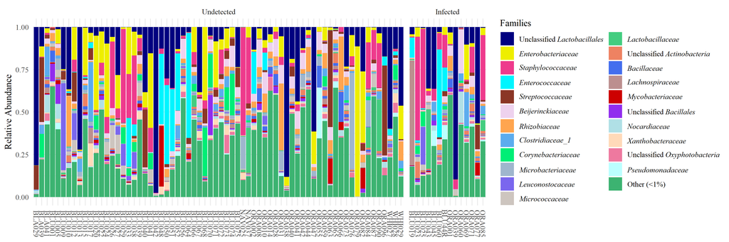

```r
library(tidyverse)

wc_top_families <- wc_agg_family_data %>%
  group_by(Family) %>%
  summarize(mean=mean(agg_rel_abund)) %>%
  arrange((desc(mean))) %>%
  top_n(22, mean) %>%
  pull(Family)
wc_top_families

##Families >1%
## [1] "Lactobacillales_unclassified"  "Enterobacteriaceae"            "Staphylococcaceae"
## [4] "Enterococcaceae"               "Streptococcaceae"              "Beijerinckiaceae"
## [7] "Rhizobiaceae"                  "Clostridiaceae_1"              "Corynebacteriaceae"
## [10] "Microbacteriaceae"             "Leuconostocaceae"              "Micrococcaceae"
## [13] "Lactobacillaceae"              "Actinobacteria_unclassified"   "Bacillaceae"
## [16] "Lachnospiraceae"               "Mycobacteriaceae"              "Bacillales_unclassified"
## [19] "Nocardiaceae"                  "Xanthobacteraceae"             "Oxyphotobacteria_unclassified"
## [22] "Pseudomonadaceae"

df0 <- wc_df %>% mutate(Family = fct_other(Family, wc_top_families))
df0$Family <- factor(df0$Family, levels = c("Lactobacillales_unclassified", "Enterobacteriaceae", "Staphylococcaceae",
                                             "Enterococcaceae", "Streptococcaceae", "Beijerinckiaceae", "Rhizobiaceae",
                                            "Clostridiaceae_1", "Corynebacteriaceae", "Microbacteriaceae", "Leuconostocaceae",
                                            "Micrococcaceae", "Lactobacillaceae", "Actinobacteria_unclassified",
                                            "Bacillaceae", "Lachnospiraceae", "Mycobacteriaceae", "Bacillales_unclassified",
                                            "Nocardiaceae",  "Xanthobacteraceae", "Oxyphotobacteria_unclassified",
                                            "Pseudomonadaceae", "Other"))
Lactobacillales <- expression(paste("Unclassified ", italic("Lactobacillales")))
Oxyphotobacteria <- expression(paste("Unclassified ", italic("Oxyphotobacteria")))
Actinobacteria <- expression(paste("Unclassified ", italic("Actinobacteria")))
Bacillales <- expression(paste("Unclassified ", italic("Bacillales")))

site.labs.plas <- c("Infected", "Undetected")
names(site.labs.plas) <- c("Y", "N")

family_plot <- ggplot(df0, aes(x=id, y=Abundance, fill=Family)) +
  geom_bar(aes(), stat="identity", position="fill") +
  scale_fill_manual(values=c("navy", "yellow2", "violetred2", "turquoise1", "tomato4", "thistle2", "tan1", "steelblue2",
                             "springgreen2", "slategray3", "slateblue2", "seashell3", "seagreen3", "salmon2", "royalblue2",
                             "rosybrown", "red3", "purple2", "powderblue", "peachpuff1", "palevioletred2", "paleturquoise1",
                             "mediumseagreen"),
                    name = "Families",
                    labels = c(Lactobacillales,
                               expression(italic("Enterobacteriaceae")),
                               expression(italic("Staphylococcaceae")),
                               expression(italic("Enterococcaceae")),
                               expression(italic("Streptococcaceae")),
                               expression(italic("Beijerinckiaceae")),
                               expression(italic("Rhizobiaceae")),
                               expression(italic("Clostridiaceae_1")),
                               expression(italic("Corynebacteriaceae")),
                               expression(italic("Microbacteriaceae")),
                               expression(italic("Leuconostocaceae")),
                               expression(italic("Micrococcaceae")),
                               expression(italic("Lactobacillaceae")),
                               Actinobacteria,
                               expression(italic("Bacillaceae")),
                               expression(italic("Lachnospiraceae")),
                               expression(italic("Mycobacteriaceae")),
                               Bacillales,
                               expression(italic("Nocardiaceae")),
                               expression(italic("Xanthobacteraceae")),
                               Oxyphotobacteria,
                               expression(italic("Pseudomonadaceae")),
                               "Other (<1%)")) +
  guides(fill=guide_legend(ncol=2)) +
  ylab("Relative Abundance") +
  xlab("Location") +
  facet_grid(~plasmodium, scales = "free_x", space = "free_x", labeller = labeller(plasmodium = site.labs.plas)) +
  theme_minimal()
family_plot <- family_plot + theme(axis.text.x = element_text(angle = -90, vjust = 0.5, hjust=1))
family_plot <- family_plot + theme(axis.title.x=element_blank())
family_plot <- family_plot + theme(legend.text.align = 0)
family_plot <- family_plot + theme(text = element_text(family = "serif"))
family_plot
```

Combine the phyla and families into one plot.

```r
library(ggpubr)
library(cowplot)
row <- plot_grid(phyla_plot, ncol = 1, labels = "a")
row2 <- plot_grid(family_plot, ncol = 1, labels = "b")
plot_grid(row, row2, nrow = 2, align="v", rel_heights = c(1, 1)) +
  theme_bw()
```

[figure not shown]

##Alpha Diversity Calculate Alpha Diversity with phyloseq, using four common diversity measurements. Convert alpha diversity into phyloseq sample_data. Merge the alpha diversity object with the primary phyloseq object so the alpha diversity values are included in the overall sample data.

```r
ad <- estimate_richness(twosites, measures=c("Observed", "Shannon", "Simpson", "InvSimpson"))
ad <- sample_data(ad)
twosites <- merge_phyloseq(twosites, ad)
twosites
```

Pull sample data and test normality visually and statistically.

```r
library(ggpubr)
alpha <- sample_data(twosites)

ggqqplot(alpha$Observed)
ggdensity(alpha$Observed)
ggqqplot(alpha$Shannon)
ggdensity(alpha$Shannon)
ggqqplot(alpha$Simpson)
ggdensity(alpha$Simpson)
ggqqplot(alpha$InvSimpson)
ggdensity(alpha$InvSimpson)

shapiro.test(alpha$Observed)
## Shapiro-Wilk normality test
## data:  alpha$Observed
## W = 0.95659, p-value = 0.006874

shapiro.test(alpha$Shannon)
## Shapiro-Wilk normality test
## data:  alpha$Shannon
## W = 0.98197, p-value = 0.2967

shapiro.test(alpha$Simpson)
## Shapiro-Wilk normality test
## data:  alpha$Simpson
## W = 0.85161, p-value = 1.219e-07

shapiro.test(alpha$InvSimpson)
## Shapiro-Wilk normality test
## data:  alpha$InvSimpson
## W = 0.5547, p-value = 1.793e-14
```

Shannon Diversity appears normally distributed, and observed richness looks okay visually but is significant with Shapiro Wilks. Simpson and InvSimpson are not normally distributed. Plot *Plasmodium* alpha diversity to visualize possible variation.

```r
ggplot(alpha, aes(x = plasmodium, y = Observed)) +
  geom_boxplot()

ggplot(alpha, aes(x = plasmodium, y = Shannon)) +
  geom_boxplot()
```

No apparent visual difference. Use ANOVAs to check statistically - test observed richness and Shannon Diversity while accounting for confounding variables.

```r
alpha_df <- as(sample_data(twosites), "data.frame")
alpha_df

anova <- aov(Observed ~ batch + age + location + plasmodium, data = alpha_df)
summary(anova)

##             Df  Sum Sq Mean Sq F value Pr(>F)
## batch        1   25234   25234   0.513  0.476
## age          1   29696   29696   0.604  0.440
## location     1   13507   13507   0.275  0.602
## plasmodium   1   16045   16045   0.326  0.570
## Residuals   77 3787277   49185

anova_shan <- aov(Shannon ~ batch + age + location + plasmodium, data = alpha_df)
summary(anova_shan)
```

```
##             Df Sum Sq Mean Sq F value Pr(>F)
## batch        1   0.10  0.0965   0.055  0.816
## age          1   1.02  1.0207   0.579  0.449
## location     1   0.55  0.5533   0.314  0.577
## plasmodium   1   0.26  0.2572   0.146  0.704
## Residuals   77 135.69  1.7622
```

Alpha diversity does not significantly vary based on any of the variables measured in the model, including *Plasmodium* presence.

Ordinate the two sites.

```r
two_pcoa <- ordinate(
  physeq = twosites,
  method = "PCoA",
  distance = "jaccard"
)
```

Now plot blood parasite infection within these two sites. First make new labels for facets as named character vector.

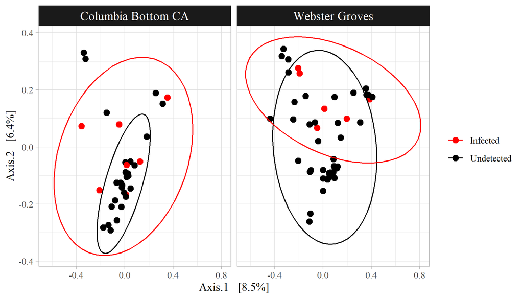

```r
site.labs <- c("Columbia Bottom CA", "Webster Groves")
names(site.labs) <- c("columbia_bottom", "webster_groves")
sample_sums(twosites)
plas <- plot_ordination(
  physeq = twosites,
  ordination = two_pcoa,
  color = "plasmodium",
  title = NULL #"PCoA of primary sites by blood parasite infection"
) +
  scale_color_manual(name=NULL,
                     values=c("red", "black"),
                     breaks=c("Y", "N"),
                     labels=c("Infected", "Undetected")
  ) +
  geom_point(aes(color = plasmodium), alpha = 1, size = 2.5) +
  facet_wrap(~ location, labeller = labeller(location = site.labs)) +
  coord_cartesian() +
  stat_ellipse() +
  theme_light()
test <- subset_samples(twosites, plasmodium=="Y")
test
plas <- plas + theme(text = element_text(family = "serif"))
plas <- plas + theme(strip.background = element_rect(fill="gray10"))
plas <- plas + theme(strip.text.x = element_text(size = 12))
plas
```

Check significance of *Plasmodium* using PERMANOVAs across both sites.

```r
library(vegan)

wgcb_jac <- phyloseq::distance(twosites, method = "jaccard")
wgcb_df <- data.frame(sample_data(twosites))

perm <- how(nperm = 999)
setBlocks(perm) <- with(wgcb_df, batch)

adonis2(wgcb_jac ~ location + season + sex + age + plasmodium, data = wgcb_df, permutations=perm)
## Permutation test for adonis under reduced model
## Terms added sequentially (first to last)
## Blocks:  with(wgcb_df, batch)
## Permutation: free
## Number of permutations: 999

## adonis2(formula = wgcb_jac ~ location + season + sex + age + plasmodium, data = wgcb_df, permutations = perm)
##            Df SumOfSqs      R2      F Pr(>F)
## location    1    0.863 0.02472 2.1032  0.001 ***
## season      2    1.814 0.05198 2.2111  0.001 ***
## sex         1    0.390 0.01118 0.9509  0.581
## age         1    0.602 0.01726 1.4688  0.019 *
## plasmodium  1    0.464 0.01330 1.1318  0.168
## Residual   75   30.763 0.88156
## Total      81   34.897 1.00000
## ---
## Signif. codes:  0 ‘***’ 0.001 ‘**’ 0.01 ‘*’ 0.05 ‘.’ 0.1 ‘ ’ 1

adonis2(wgcb_jac ~ location + season + age + plasmodium, data = wgcb_df, permutations=perm)
## Permutation test for adonis under reduced model
## Terms added sequentially (first to last)
## Blocks:  with(wgcb_df, batch)
## Permutation: free
## Number of permutations: 999

## adonis2(formula = wgcb_jac ~ location + season + age + plasmodium, data = wgcb_df, permutations = perm)
##            Df SumOfSqs      R2      F Pr(>F)
## location    1    0.872 0.02510 2.1387  0.001 ***
## season      2    1.824 0.05249 2.2363  0.001 ***
## age         1    0.595 0.01713 1.4598  0.024 *
## plasmodium  1    0.465 0.01337 1.1393  0.169
## Residual   76   30.997 0.89191
## Total      81   34.754 1.00000
## ---
## Signif. codes:  0 ‘***’ 0.001 ‘**’ 0.01 ‘*’ 0.05 ‘.’ 0.1 ‘ ’ 1

beta <- betadisper(wgcb_jac, wgcb_df$plasmodium)
permutest(beta)

## Permutation test for homogeneity of multivariate dispersions
## Permutation: free
## Number of permutations: 999

## Response: Distances
##           Df   Sum Sq   Mean Sq     F N.Perm Pr(>F)
## Groups     1 0.007106 0.0071057 8.528    999  0.004 **
## Residuals 80 0.066658 0.0008332
## ---
## Signif. codes:  0 ‘***’ 0.001 ‘**’ 0.01 ‘*’ 0.05 ‘.’ 0.1 ‘ ’ 1

beta <- betadisper(wgcb_jac, wgcb_df$location)
permutest(beta)

##Permutation test for homogeneity of multivariate dispersions
##Permutation: free
##Number of permutations: 999

##Response: Distances
##          Df   Sum Sq    Mean Sq      F N.Perm Pr(>F)
##Groups     1 0.001675 0.00167475 1.9427    999  0.176
##Residuals 80 0.068965 0.00086206

beta <- betadisper(wgcb_jac, wgcb_df$season)
permutest(beta)

##Permutation test for homogeneity of multivariate dispersions
##Permutation: free
##Number of permutations: 999

##Response: Distances
##          Df   Sum Sq   Mean Sq      F N.Perm Pr(>F)
##Groups     2 0.007159 0.0035797 1.9427    999  0.147
##Residuals 79 0.145564 0.0018426

beta <- betadisper(wgcb_jac, wgcb_df$age)
permutest(beta)

##Permutation test for homogeneity of multivariate dispersions
##Permutation: free
##Number of permutations: 999

##Response: Distances
##          Df   Sum Sq    Mean Sq      F N.Perm Pr(>F)
##Groups     1 0.000267 0.00026658 0.2689    999  0.616
##Residuals 80 0.079319 0.00099148
```

Limit to samples from Webster Groves.

```r
wg <- subset_samples(twosites, location=="webster_groves")
```

Check significance at this site.

```r
library(vegan)

wg_jac <- phyloseq::distance(wg, method = "jaccard")
wg_df <- data.frame(sample_data(wg))

perm <- how(nperm = 999)
setBlocks(perm) <- with(wg_df, batch)

adonis2(wg_jac ~ season + age + sex + plasmodium, data = wg_df, permutations=perm)
## Permutation test for adonis under reduced model
## Terms added sequentially (first to last)
## Blocks:  with(wg_df, batch)
## Permutation: free
## Number of permutations: 999

## adonis2(formula = wg_jac ~ season + age + sex + plasmodium, data = wg_df, permutations = perm)
##            Df SumOfSqs      R2      F Pr(>F)
## season      2   1.8934 0.09872 2.4404  0.001 ***
## age         1   0.5695 0.02969 1.4682  0.034 *
## sex         1   0.4077 0.02126 1.0510  0.340
## plasmodium  1   0.4047 0.02110 1.0431  0.424
## Residual   41  15.9048 0.82924
## Total      46  19.1801 1.00000
## ---
## Signif. codes:  0 ‘***’ 0.001 ‘**’ 0.01 ‘*’ 0.05 ‘.’ 0.1 ‘ ’ 1

adonis2(wg_jac ~ season + age + plasmodium, data = wg_df, permutations=perm)
## Permutation test for adonis under reduced model
## Terms added sequentially (first to last)
## Blocks:  with(wg_df, batch)
## Permutation: free
## Number of permutations: 999

## adonis2(formula = wg_jac ~ season + age + plasmodium, data = wg_df, permutations = perm)
##            Df SumOfSqs      R2      F Pr(>F)
## season      2   1.8934 0.09872 2.4383  0.001 ***
## age         1   0.5695 0.02969 1.4669  0.021 *
## plasmodium  1   0.4105 0.02140 1.0573  0.365
## Residual   42  16.3066 0.85019
## Total      46  19.1801 1.00000
## ---
## Signif. codes:  0 ‘***’ 0.001 ‘**’ 0.01 ‘*’ 0.05 ‘.’ 0.1 ‘ ’ 1

beta <- betadisper(wg_jac, wg_df$plasmodium)
permutest(beta)
## Permutation test for homogeneity of multivariate dispersions
## Permutation: free
## Number of permutations: 999

## Response: Distances
##           Df   Sum Sq   Mean Sq      F N.Perm Pr(>F)
## Groups     1 0.014161 0.0141606 17.559    999  0.001 ***
## Residuals 45 0.036292 0.0008065
## ---
## Signif. codes:  0 ‘***’ 0.001 ‘**’ 0.01 ‘*’ 0.05 ‘.’ 0.1 ‘ ’ 1
```

Now limit to only samples from Columbia Bottom.

```r
cb <- subset_samples(twosites, location=="columbia_bottom")
```

Check PERMANOVAs.

```r
library(vegan)

cb_jac <- phyloseq::distance(cb, method = "jaccard")
cb_df <- data.frame(sample_data(cb))

perm <- how(nperm = 999)
setBlocks(perm) <- with(cb_df, batch)

adonis2(cb_jac ~ season + age + sex + plasmodium, data = cb_df, permutations=perm)
## Permutation test for adonis under reduced model
## Terms added sequentially (first to last)
## Blocks:  with(cb_df, batch)
## Permutation: free
## Number of permutations: 999

## adonis2(formula = cb_jac ~ season + age + sex + plasmodium, data = cb_df, permutations = perm)
##            Df SumOfSqs      R2      F Pr(>F)
## season      2   1.0952 0.07450 1.2874  0.204
## age         1   0.3897 0.02651 0.9161  0.688
## sex         1   0.4622 0.03144 1.0866  0.247
## plasmodium  1   0.4190 0.02850 0.9849  0.456
## Residual   29  12.3354 0.83906
## Total      34  14.7014 1.00000

adonis2(cb_jac ~ season + age + plasmodium, data = cb_df, permutations=perm)

## Permutation test for adonis under reduced model
## Terms added sequentially (first to last)
## Blocks:  with(cb_df, batch)
## Permutation: free
## Number of permutations: 999

## adonis2(formula = cb_jac ~ season + age + plasmodium, data = cb_df, permutations = perm)
##            Df SumOfSqs      R2      F Pr(>F)
## season      2   1.0952 0.07450 1.2792  0.206
## age         1   0.3897 0.02651 0.9103  0.704
## plasmodium  1   0.3740 0.02544 0.8736  0.785
## Residual   30  12.8425 0.87356
## Total      34  14.7014 1.00000
```

```r
clean_ps
##phyloseq-class experiment-level object
##otu_table()   OTU Table:         [ 9397 taxa and 88 samples ]
##sample_data() Sample Data:       [ 88 samples by 64 sample variables ]
##tax_table()   Taxonomy Table:    [ 9397 taxa by 6 taxonomic ranks ]

filtered <- prune_samples(sample_sums(clean_ps) > 4000, clean_ps)
filtered
##phyloseq-class experiment-level object
##otu_table()   OTU Table:         [ 9397 taxa and 82 samples ]
##sample_data() Sample Data:       [ 82 samples by 64 sample variables ]
##tax_table()   Taxonomy Table:    [ 9397 taxa by 6 taxonomic ranks ]

#Remove taxa not seen more than 3 times in at least 5% of the samples.
filtered <- filter_taxa(filtered, function(x) sum(x > 3) > (0.05*nsamples(filtered)), TRUE)
filtered
##phyloseq-class experiment-level object
##otu_table()   OTU Table:         [ 577 taxa and 82 samples ]
##sample_data() Sample Data:       [ 82 samples by 64 sample variables ]
##tax_table()   Taxonomy Table:    [ 577 taxa by 6 taxonomic ranks ]
sample_names(filtered)
```

Load the package DESeq2 and convert the phyloseq object to DESeq2. Put covariates into the formula with the variable of interest placed at the end (far right). Use relevel() to make sure that the reference level is set to “N” for uninfected individuals. After running the model, doublecheck the output by using mcols(res)$description.

```r
library(DESeq2)
dstwo <- phyloseq_to_deseq2(filtered, ~ batch + age + season + location + plasmodium)

gm_mean = function(x, na.rm=TRUE){
  exp(sum(log(x[x > 0]), na.rm=na.rm) / length(x))
}
geoMeans = apply(counts(dstwo), 1, gm_mean)

dstwo = estimateSizeFactors(dstwo, geoMeans = geoMeans)

#Use relevel to make sure that uninfected individuals are set as the reference level
dstwo$plasmodium = relevel(dstwo$plasmodium, "N")
dstwo$plasmodium

#Run DESeq2
dstwo = DESeq(dstwo)

res = results(dstwo)
res = res[order(res$padj, na.last=NA), ]
alpha = 0.01  ##Default is 0.1
sigtab = res[(res$padj < alpha), ]
sigtab = cbind(as(sigtab, "data.frame"), as(tax_table(filtered)[rownames(sigtab), ], "matrix"))
head(sigtab)

plotMA(res)

#Check what the model tested
mcols(res)$description
##[1] "mean of normalized counts for all samples" "log2 fold change (MLE): plasmodium Y vs N"
##[3] "standard error: plasmodium Y vs N"         "Wald statistic: plasmodium Y vs N"
##[5] "Wald test p-value: plasmodium Y vs N"      "BH adjusted p-values"
```

Plot with Families and Phyla. Most of the significant taxa are enriched for infected individuals. Graph shows infected individuals relative to undetected.

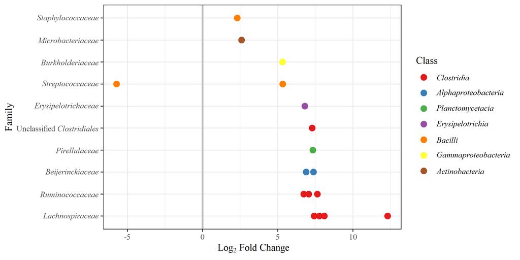

```r
library("ggplot2")

sigtabfam <- subset(sigtab, !is.na(Family))
# Phylum order
x = tapply(sigtabfam$log2FoldChange, sigtabfam$Phylum, function(x) max(x))
x = sort(x, TRUE)
sigtabfam$Phylum = factor(as.character(sigtabfam$Phylum), levels=names(x))
# Family order
x = tapply(sigtabfam$log2FoldChange, sigtabfam$Family, function(x) max(x))
x = sort(x, TRUE)
sigtabfam$Family = factor(as.character(sigtabfam$Family), levels=names(x))
des_phyla <- ggplot(sigtabfam, aes(y=Family, x=log2FoldChange, color=Phylum)) +
  xlab(expression(~Log[2]~Fold~Change)) +
  geom_vline(xintercept = 0.0, color = "gray", size = 1) +
  geom_point(size=3) +
  scale_fill_brewer(labels = c(expression(italic("Firmicutes", "Proteobacteria", "Planctomycetes", "Actinobacteria")))) +
  theme(axis.text.x = element_text(angle = -90, hjust = 0, vjust=0.5)) +
  theme_bw()
des_phyla <- des_phyla + theme(text = element_text(family = "serif"))
des_phyla
##Source: https://bioconductor.org/packages/devel/bioc/vignettes/phyloseq/inst/doc/phyloseq-mixture-models.html

##Now with Class and Family (not Phylum)
#Class order
x = tapply(sigtabfam$log2FoldChange, sigtabfam$Class, function(x) max(x))
x = sort(x, TRUE)
sigtabfam$Class = factor(as.character(sigtabfam$Class), levels=names(x))
# Family order
x = tapply(sigtabfam$log2FoldChange, sigtabfam$Family, function(x) max(x))
x = sort(x, TRUE)
sigtabfam$Family = factor(as.character(sigtabfam$Family), levels=names(x))
clostridiales <- expression(paste("Unclassified ", italic("Clostridiales")))
des_class <- ggplot(sigtabfam, aes(y=Family, x=log2FoldChange, color=Class)) +
  xlab(expression(~Log[2]~Fold~Change)) +
  scale_y_discrete("Family", labels = c(expression(italic("Lachnospiraceae")),
                                        expression(italic("Ruminococcaceae")),
                                        expression(italic("Beijerinckiaceae")),
                                        expression(italic("Pirellulaceae")),
                                        clostridiales,
                                        expression(italic("Erysipelotrichaceae")),
                                        expression(italic("Streptococcaceae")),
                                        expression(italic("Burkholderiaceae")),
                                        expression(italic("Microbacteriaceae")),
                                        expression(italic("Staphylococcaceae")))) +
  geom_vline(xintercept = 0.0, color = "gray", size = 1) +
  geom_point(size=3) +
  scale_color_brewer(palette = "Set1",
                     "Class", labels = c(expression(italic("Clostridia")),
                                expression(italic("Alphaproteobacteria")),
                                expression(italic("Planctomycetacia")),
                                expression(italic("Erysipelotrichia")),
                                expression(italic("Bacilli")),
                                expression(italic("Gammaproteobacteria")),
                                expression(italic("Actinobacteria")))) +
  theme(axis.text.x = element_text(angle = -90, hjust = 0, vjust=0.5)) +
  theme_bw()
des_class <- des_class + theme(text = element_text(family = "serif"))
des_class <- des_class + theme(legend.text.align = 0)
des_class

library("openxlsx")
sig_excel <- write.xlsx(sigtab, file = "sigtab.xlsx", colNames = TRUE, rowNames = TRUE)
sig_excel
```